# Enron Submission Free -- Response Questions

**1. Summarize for us the goal of this project and how machine learning is useful in trying to accomplish it. As part of your answer, give some background on the dataset and how it can be used to answer the project question. Were there any outliers in the data when you got it, and how did you handle those?**

The goal of this project is to bring a model which is able to predict the person of interest / "Poi" in the famous scandal of Enron Company. If we can identify the financial criminals beforehands, the catastrophic like the collapse of Enron might be prevented in the future.

In machine learning, the model firstly observes the certain characteristics of the Enron employees' behaviours or "features" in the dataset, which will be classified in different labels. In this case, the labels tell whether the persion is Poi or not. This process is called "training". By using algorithms to find a way to classify the employees in these 2 groups, we are then able to identify Poi according to the features we have considered during the training process.

At last, in order to ensure that our model is good to make prediction, a part of the dataset will be used as testing set. Its features data will be substituted into the model to see if the model have the same result as the labels in the testing set, so-called "testing".

In order to have fair training and testing processes, at first, we need to clean our dataset if there are any improper data points or outliers in our dataset. The way to tickle this problem is to choose two features to observe their distribution and see if there are any abnormal data points.

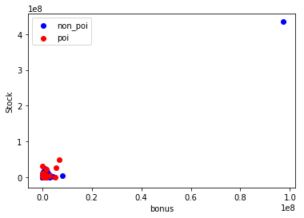

```python
import sys
import pickle
import math
import matplotlib.pyplot as plt
import numpy
sys.path.append("../tools/")
from feature_format import featureFormat, targetFeatureSplit

features_list = ['poi','bonus', 'total_stock_value']

with open("final_project_dataset.pkl", "r") as data_file:
    data_dict = pickle.load(data_file)


def visual(features, labels):
	feature_1_normal = [features[ii][0] for ii in range(0, len(features)) if labels[ii]==0]
	feature_2_normal = [features[ii][1] for ii in range(0, len(features)) if labels[ii]==0]
	feature_1_poi = [features[ii][0] for ii in range(0, len(features)) if labels[ii]==1]
	feature_2_poi = [features[ii][1] for ii in range(0, len(features)) if labels[ii]==1]


#### initial visualization
	plt.scatter(feature_1_normal, feature_2_normal, color = "b", label="non_poi")
	plt.scatter(feature_1_poi , feature_2_poi, color = "r", label="poi")
	plt.legend()
	plt.xlabel("bonus")
	plt.ylabel("Stock")
	plt.show()


my_dataset = data_dict
data = featureFormat(my_dataset, features_list, sort_keys = True)
labels, features = targetFeatureSplit(data)


visual(features, labels)
```

As we can see, there is a special point in our dataset, whose values of "bonus" and "total_stock_value" are tremendously high. We can check our dataset and look for the person whose total stock value is over 4e+08 or 4 * 10^8:

```python
import math
for name, data in data_dict.iteritems():
	if data['total_stock_value'] > 4e+08:
		if not math.isnan(float(data['total_stock_value'])):
			print name
```

```
TOTAL
```

Just like the outlier we have met in the course of Udacity. The outlier's features sum up the number of all the person in the dataset and provide no value to our dataset, since we concentrate on the individuals' feature, so that we can just feel free to delete this row of dataset. Then the distribution graph will now look like this:

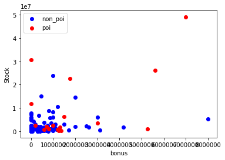

```python
data_dict.pop('TOTAL', 0)

my_dataset = data_dict
data = featureFormat(my_dataset, features_list, sort_keys = True)
labels, features = targetFeatureSplit(data)

visual(features, labels)
```

And as we have done before, we check if the outliner-alike data point with large value of total stock should be eliminated:

```python
import math
for name, data in data_dict.iteritems():
	if data['total_stock_value'] > 4e+07:
		if not math.isnan(float(data['total_stock_value'])):
			print name
```

```
LAY KENNETH L
```

The name of the CEO comes out and we should not exclude him because he played an important role in the scandel and his data is of course valid. Let's try another data point with a huge number of bonus:

```python
import math
for name, data in data_dict.iteritems():
	if data['bonus'] > 7000000:
		if not math.isnan(float(data['bonus'])):
			print name
```

```
LAVORATO JOHN J
```

It seems a valid data point as well. We can then assume that there is no outliner in our dataset anymore and we can start the next step of the investigation.

Udacity's Tutor told me that there were two more outliners needed to be cleaned: "THE TRAVEL AGENCY IN THE PARK" and "LOCKHART EUGENE E".

The first one isn't even a person and very likely not a part of Enron, we can then considered it as incorrectly entered data, since we want to find out the person of interest in the model. We need to clean this data point, though it may be one of the parties which have trades with Enron.

The second one has null values in all the features and provides no informations, so this data point isn't going to help us either in the section of training or testing, so it should be removed as well.

In order to prevent the second type of outliners, I've written a function which can detect if the data point has too many missing points:

```
features_valid = ['salary', 'deferral_payments', 'total_payments', 'loan_advances', 'bonus', 'restricted_stock_deferred', 'deferred_income', 'total_stock_value', 'expenses', 'exercised_stock_options', 'other', 'long_term_incentive', 'restricted_stock', 'director_fees',
'to_messages', 'from_poi_to_this_person', 'from_messages', 'from_this_person_to_poi', 'shared_receipt_with_poi']

#delect email address, since if we use isnan to testify if the data point, we need float form, which we can not use on sting
#delect poi, it will return either true or false but never nan!

# check if there is a datapoint with Null datapoint
def nan_checker(data_dict, number):
    # use to find out all nan datapoint:
    for name, data in data_dict.iteritems():
        i = 0
        for x in features_valid:
            if math.isnan(float(data[x])):
                i += 1
        if i == number: # change the number if you're unsatisfied by the data point with too many nans
            print name
            print data

nan_checker(data_dict, len(features_valid))  #find out the person who fail all of the features
```

**2. What features did you end up using in your POI identifier, and what selection process did you use to pick them? Did you have to do any scaling? Why or why not? As part of the assignment, you should attempt to engineer your own feature that does not come ready made in the dataset -- explain what feature you tried to make, and the rationale behind it. In your feature selection step, if you used an algorithm like a decision tree, please also give the feature importances of the features that you use, and if you used an automated feature selection function like SelectKBest, please report the feature scores and reasons for your choice of parameter values.**

I end up using three features:

- from_messages
- total_stock_value
- deferred_income

At the first time of the submission to Udacity, I used these three features as my final choices:

- bonus
- total_stock_value
- deferred_income

The reason why I choose the first two features is because they are important factors to stimulate the Enron staffs planning scams by pretending the company to have hugh profits and healthy financial statements, so that they can gain more from the bonus and attract more people to invest the company, which at the end pushes up the price of the stock and indirectly influences the value of their stocks.

The third feature is chosen since I notice that in the original report of our dataset "Enron Statement of Financial Affairs (In re: Enron Corp.) 01-16034", some of the pois like John C Baxter and Kennth D Rice have great number of deferred income. Some non-Poi like Kevin P Hannon has larger amount of deferred income, but he doesn't have the huge value of total stock value at the same time as the two pois have. Therefore, I think it may be a good feature to be included.

The reason why I used from_messages instead of bonus was because the Udacity's mentor suggested that I might try some features about email, since the number of sending or receiving email should be related to whether a person is important to the company.

Moreover, the result was not hugely damaged when I excluded bonus out of the feature list, therefore I think it should be replaced.

In the final choice of my algorithm, Gaussian Naive Bayes, I doesn't create any scaling since in the classification process the algorithm only considers the probability rather than the distance of features' values between each other. But I scale them when I use another algorithm because it gets involved with the method of K-means Clustering, which will considers the matter of distance.

For the attempt of creating new feature, I create a feature of 'fraction_of_exercised_stock', which calculates the proportion of exercised stock options in the number of total stock value, as the poi might want to exercise their stock options earlier in order to exchange their stocks into cashes at the pike of the stock price, before the bad news come.

It seems not a good feature. Let's say if I change the feature combination into:

- bonus
- fraction_of_exercised_stock
- deferred_income

There's no point to use the feature of total_stock_value together, since the correlation between its fraction and the total value must be bigger than zero and will cause biased situation in our model.

For example if we train our model with the GaussianNB algorithms again, which we use in the final version, the result of scores according to tester.py will be:

```
Accuracy: 0.87107    Precision: 0.60167    Recall: 0.28850
F1: 0.39000
```

the Recall score move down to 0.28 and the Precision will move up to 0.60167. Since we need to keep both of the scores higher than 0.3, so I doesn't include it in the final version.

It can be explaned that poi might expect better price of the stock in the future and hold it for a while, so there are some pois who kept waiting and the algorithm will judge them as non-poi, so that the Recall score move down because of the increase of False Negatives.

But still, this is a very interesting feature, because it brings the greatest Precision score I have ever met in my project, which is larger than 0.5 and greater than a mere guess. Maybe the one who rushes having the stock is very likely a poi?

Having the instruction from the mentor, I've also tried SelectKBest to find out the most related features:

```
features_list = ['poi', 'salary', 'deferral_payments', 'total_payments', 'loan_advances', 'bonus', 'restricted_stock_deferred', 'deferred_income', 'total_stock_value', 'expenses', 'exercised_stock_options', 'other', 'long_term_incentive', 'restricted_stock', 'director_fees',
'to_messages', 'from_poi_to_this_person', 'from_messages', 'from_this_person_to_poi', 'shared_receipt_with_poi']

my_dataset = data_dict
data = featureFormat(my_dataset, features_list, sort_keys = True)
label, features = targetFeatureSplit(data)

features_train, features_test, labels_train, labels_test = train_test_split(features, label, test_size=0.1, random_state=42)

sfm = SelectKBest(f_classif, k=3).fit(features_train,labels_train)

print sfm.scores_

index = sfm.get_support(indices=True)
print index
features_list_best = features_list[1:]
for i in index:
      print features_list_best[i] #print the features with best k socres
```

The result will be:

```
[ 20.75819764   0.07056005   8.75720115   6.76321871  33.07230983
   0.07054169  11.23694023  15.78178978   4.72981234  15.48995797
   3.87862368  11.85680446   9.15789004   2.10199584   2.21719475
   9.61003011   0.12413113   3.31395783  11.31410173]
[0 4 7]
salary
bonus
total_stock_value
```

If we follow this combination in our GaussianNB Algorithm, the score will be:

```
Accuracy: 0.84146    Precision: 0.47589    Recall: 0.30100
F1: 0.36876
```

Sadly, it doesn't beat the first and second combination we mentioned in this section before in all the four socres. (For detailed comparsion, readers can find the result in the appendix section)

**3. What algorithm did you end up using? What other one(s) did you try? How did model performance differ between algorithms?**

I end up using one of the simplest algorithm out of our course -- Gaussian Naive Bayes.

```
clf = GaussianNB()
```

I've tried other algorithms like Support Vector Machine, Decision Trees and Clustering. In order to boost the performance of algorithms, I picks several algorithms which performance good in Precision and Recall scores -- K-means Clustering with scaled features and Random Forest. Then I combine them with the GaussianNB to build a voting model, which means every judgement on whether the person in the test set is poi or not need to have an agreement with the majority of three algorithms.

```
clf1 = KMeans(n_clusters=2)
clf2 = RandomForestClassifier(random_state=5, max_depth=6)
clf3 = GaussianNB()

Vote_clf = VotingClassifier(estimators=[('knn', clf1), ('rf', clf2),('gnb', clf3)],
    voting='hard')

clf = Pipeline(steps=[
    ('scaler', MinMaxScaler()),
    ('voting', Vote_clf),
    ]) # put the classifier into the pipeline
```

According to the result of tester.py which checks the performance of the algorithm 1000 times in order to provide trustable tests, the scores of applying GaussianNB is:

```
Accuracy: 0.85971   Precision: 0.51302  Recall: 0.35450 F1: 041928
```

And the scores of applying the voting algorithm is:

```
Accuracy: 0.86086   Precision: 0.52338  Recall: 0.29100 F1: 037404
```

I think it is because the Clustering and Random Forest perform relative bad in preventing false negative, especially the Random Forest. When they meet a poi data point, both of them may not discover it is poi and win the vote by forming the majority.

Also there is a huge difference in the speed of computing, since each judgement needs to go through all three algorithms. The file of tester.py just needs about 2 seconds to run the GaussianNB and about 55 seconds to run the voting algorithm.

So I choose the first solution instead, even though it is a quite straightforward solution.

**4. What does it mean to tune the parameters of an algorithm, and what can happen if you don’t do this well? How did you tune the parameters of your particular algorithm?**

For the parameters of Random Forest, I've tried tunning important parameters like max_depth, which determines if the trees should grow further in classification. There is an example of using GridSearchCV to avoid manually searching for the best parameters:

```
clf = RandomForestClassifier(random_state=5, max_depth=6)

param_grid = {
    'n_estimators': [10, 40, 50, 70, 100],
    'max_features': ['auto', 'sqrt', 'log2'],
    'max_depth': [2, 3, 4, 5, 6, 7, 8, 9, 10],
    'random_state':[1, 2, 3, 4, 5, 6, 7, 8, 9, 10]
    }

cv_clf = GridSearchCV(estimator=clf, param_grid=param_grid, cv= 5, scoring='recall') # Since Decision Forest doesn't perform well in avoiding false negatives
cv_clf.fit(features_train, labels_train)
print cv_clf.best_params_
```

But for a mysterious reason, the recommanded combination of n_estimators, random_state and max_depth which doesn't outperform my default try on the parameters, random_state=5, max_depth=6 in the result of tester.py. The reason may be because the scoring system of GridSearchCV is based on the score of the current random state, whose result may not be as stable as tester.py's.

The parameter of Clustering is obvious, since we want to distinguish whether an Enron member is a poi or not, it should be classified in 2 groups -- poi or non-poi, so the number of clustering should also be 2.

The algorithm of GaussianNB doesn't need to be tuned, but it can be used as base estimator of the Adaboost, which can learn errors from the previous weak learners and improve the performance.

```
from sklearn.naive_bayes import GaussianNB
from sklearn.ensemble import AdaBoostClassifier
clf = AdaBoostClassifier(base_estimator = GaussianNB())
```

If we use the feature combination of "bonus + total stock value + deferred income", the result of Adaboost will be:

[output not shown]

Comparing to the normal GaussianNB:

```
Accuracy: 0.85971    Precision: 0.51302    Recall: 0.35450
F1: 0.41928
```

**5. What is validation, and what’s a classic mistake you can make if you do it wrong? How did you validate your analysis?**

Validation is the method to test how our model performs, since our model may make the mistake of overfitting, which means our model may be formed too complexly to fit every data point of training data. In order to prevent this problem, we use cross validation to evaluate our result.

There are few ways to achieve the cross validation:

- Hold out Method

We split 50% to 70 % of our sample into training sample and 50% to 30% into testing/holding out sample. After we train our model based on the training set, we evaluate the model with the testing set.

Example using sklearn:

```
from sklearn.cross_validation import train_test_split
features_train, features_test, labels_train, labels_test = \
    train_test_split(features, labels, test_size=0.3, random_state=42)
```

It is fast to compute the result, but it may cause "Selection bias", which means that we may have different evaluation results because of different divisions and the performance of the algorithm may not be judged fairly, so that we might get very different results when we change the parameter of random_state to randomize the division.

- K-Fold CV

We split the dataset into K size or K folds of sub-samples, then we use K - 1 sub-samples as the training set and the remaining fold as testing set. And we repeat this process K times until all of the sub-samples have once been used as testing set. At last, we will get the average result of the evaluation.

During this process, we randomize the process and avoid the Error we will meet if we use Hold out Method.

Here's a Example according to our Enron dataset, assuming K = 15:

```
kf = KFold(n_splits=15, shuffle=True)

# it will print which data point we have taken and score of each fold for 15 times

for train_indices, test_indices in kf.split(labels):
    print ("TRAIN:", train_indices, "TEST:", test_indices)
    features_train = [features[ii] for ii in train_indices]
    features_test = [features[ii] for ii in test_indices]
    labels_train = [labels[ii] for ii in train_indices]
    labels_test = [labels[ii] for ii in test_indices]

    clf = GaussianNB()
    clf.fit(features_train, labels_train)
    pred = clf.predict(features_test)
    print "precision:", precision_score(labels_test, pred)
    print "recall:", recall_score(labels_test, pred)
    print "--------one round over------------"


# if we want to get the average score instead of printing out all the results:

from sklearn.model_selection import cross_val_score
scores = cross_val_score(clf, features_train, labels_train, cv=kf, scoring='recall_macro')
avg_score = np.mean(scores)
print(avg_score)
```

- Leave one out CV

It is a variation of K-Fold CV. Assuming we have N data points, we split the dataset into N folds of sub-samples. As we have done in K-Fold CV, this time we use our N - 1 sub-samples as the training set and the remaining one as the testing set. Since we have N folds, so we need to repeat the process N times to get the average reslult.

- Bootstrap Methods

Full name should be "Boostrap aggregating - bagging": we have N number of instances in our training set. We then take N' number of instances and form a bag of training set. And N' should be less than N.

To randomize the process, after we form our dataset into the first bag, we form the second bag with replacements, as if we have done with the dataset at the first time, that means taking out datapoints to form one bag will not affect how we form the other bags and we might have the bags with similar datapoints.

Then we train the model with M number of bags and get the average score of M times evaluations with the testing set.

At first, I validated the result via Hold out Method without tunning the random state and once found a result with excellent scores, but then Udacity's mentor reminded me that the result was not believable because of the small size of our dataset. I just met a part of the dataset which was accidentally favorable to my model. After I use tester.py to test my model or just tune the parameter of the random state, the number of score will drop down significantly.

**6. Give at least 2 evaluation metrics and your average performance for each of them. Explain an interpretation of your metrics that says something human--understandable about your algorithm’s performance.**

In this project, I always look for two merics: Precision and Recall, since they focus on whether we can identify poi in our algorithm, or produce "true positive".

Secondly, the aim of model is to identify poi, that means a model which perfectly finds out all of the non-pois but fail to find out any pois is totally useless.

Here's the performance of final version:

```
Accuracy: 0.86643    Precision: 0.54571    Recall: 0.38800
F1: 0.45354
```

My algorithm get 0.54571 in Precision and 0.38800 in Recall. It can be interpreted as: the prediction can be 50/50 true, when algorithm says someone is a poi; but when it says someone isn't poi, there is more possible that the prediction has made a mistake.

## Appendix: Selections of results using tester.py

*I haven't compared with the differences between without or with the specific feature_range in MinMaxScaler when I use Voting or Clustering, since it's horribly time consuming.

*The order of algorithm follows the number of F1-score

### Features Combination 1:

- from_messages
- total_stock_value
- deferred_income

GausainNB:

```
Accuracy: 0.86643    Precision: 0.54571    Recall: 0.38800
F1: 0.45354
```

Voting Classifier (Clustering + Random Forest + GaussianNB, MinMaxScaler(feature_range=(0, 1)):

```
Accuracy: 0.85564    Precision: 0.48855    Recall: 0.22400
F1: 0.30716
```

Voting Classifier (Clustering + Adaboost with GaussianNB as base estimator + GaussianNB, MinMaxScaler(feature_range=(0, 1)):

```
Accuracy: 0.81669    Precision: 0.34213    Recall: 0.20750
F1: 0.25833
```

Clustering, no specific feature_range in scaling:

```
Accuracy: 0.76436   Precision: 0.22160  Recall: 0.25850 F1: 0.23863
```

### Features Combination 2:

- bonus
- total_stock_value
- deferred_income

GausainNB:

```
Accuracy: 0.85971    Precision: 0.51302    Recall: 0.35450
F1: 0.41928
```

Voting Classifier (Clustering + Random Forest + GaussianNB, MinMaxScaler(feature_range=(0, 1)):

```
Accuracy: 0.86086    Precision: 0.52338    Recall: 0.29100
F1: 0.37404
```

Adaboost, GaussianNB as base estimator:

```
Accuracy: 0.71371    Precision: 0.21347    Recall: 0.37400
F1: 0.27180
```

Clustering, no specific feature_range in scaling:

```
Accuracy: 0.72243   Precision: 0.20678  Recall: 0.33250 F1: 0.25498
```

### Features Combination 3:

- bonus
- fraction_of_exercised_stock
- deferred_income

GausainNB:

```
Accuracy: 0.87107    Precision: 0.60167    Recall: 0.28850
F1: 0.39000
```

Clustering, no specific feature_range in scaling:

```
Accuracy: 0.51543   Precision: 0.14782  Recall: 0.50200 F1: 0.22839
```

### Features Combination 4:

GausainNB:

```
Accuracy: 0.84146    Precision: 0.47589    Recall: 0.30100
F1: 0.36876
```

Voting Classifier (Clustering + Random Forest + GaussianNB, MinMaxScaler(feature_range=(0, 1)):

```
Accuracy: 0.83815    Precision: 0.43048    Recall: 0.16100
F1: 0.23435
```

Clustering, no specific feature_range in scaling:

```
Accuracy: 0.73700   Precision: 0.17753  Recall: 0.23150 F1: 0.20095
```